# RNA_Seq_Methods_NotesUpdated

Jose_Robledo

2024

# RNA-Sequencing experimental analysis workflow using *Caenorhabditis elegans*

**Jose Robledo, Saifun Ripa Nahar, Manuel A. Ruiz, Raymond J. Hendricks, David J. Burks, Mary L. Ladage, Taegun Kwon, Rajeev K. Azad, Pamela A. Padilla<sup>1</sup>**

<sup>1</sup>Department of Biological Sciences, University of North Texas, Denton, TX 76203

Key Words: RNA sequencing, Bioinformatic pipeline, Differentially expressed genes, Reproducibility

Corresponding Authors:

```r
Corresponding Author:
Pamela A. Padilla (PI)
University of North Texas
Department of Biological Sciences
1155 Union Circle #305220
Denton, TX 76203
(940)565-3614
pamela.padilla@unt.edu

Jose Robledo (Bioinformatic Graduate Student)
University of North Texas
Department of Biological Sciences
1155 Union Circle #305220
Denton, TX 76203
JoseRobledo@my.unt.edu
```

# Abstract

RNA sequencing is an approach to transcriptomic profiling that enables the detection of differentially expressed genes in response to genetic mutation or experimental treatment, among other uses. Here we describe a method for the use of a customizable, user-friendly bioinformatics pipeline to identify differentially expressed genes in RNA sequencing data obtained from *C. elegans*, with attention to the improvement in reproducibility and accuracy of results.

# 3. Methods

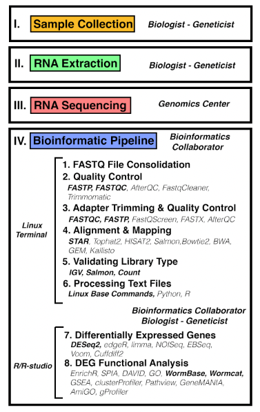

**Fig. 1 Experimental Workflow**